# **섹션 1: 그래프 이론**

## **그래프 이론: 방향성 및 무방향성 그래프**

그래프의 엣지는 노드 간에 방향성 의존성이 존재하는지 여부에 따라 **방향성(directed)** 또는 **무방향성(undirected)**일 수 있습니다. 방향성 그래프에서 엣지에는 소스 노드와 목적지 노드가 있습니다. 무방향성 그래프에서 정보는 양방향으로 흐르므로 대칭성을 가질 수 있습니다. 즉, 무방향성 그래프에서 A[i][j] = A[j][i]입니다. 다시 말해, n0에서 n1 사이의 무방향성 엣지를 갖는 것은 n0에서 n1로, n1에서 n0로의 두 개의 방향성 엣지를 갖는 것과 같습니다.

아래는 화살표로 방향을 나타내는 각각의 예입니다.

```python
# @title The graph on the left is directed, with 4 nodes and 5 edges. Note that there is an edge from node 0 to 1, but not from node 1 to 0. The graph on the right is undirected.


# Create a directed graph (using DiGraph) with 4 nodes and 5 edges
G_directed = nx.DiGraph()
G_directed.add_edges_from([(0, 1), (0, 2), (1, 2), (2, 3), (3, 1)])

# Create an undirected graph with the same 4 nodes but undirected edges
G_undirected = nx.Graph()
G_undirected.add_edges_from([(0, 1), (0, 2), (1, 2), (2, 3), (3, 1)])

fig, axes = plt.subplots(1, 2, figsize=(11, 4))

# Plot directed graph on the left
pos = nx.spring_layout(G_directed)
nx.draw(G_directed, pos, ax=axes[0], with_labels=True, node_color='lightblue', node_size=700, arrows=True)
axes[0].set_title("Directed Graph")

# Print directed adjacency matrix
A_directed = nx.adjacency_matrix(G_directed).todense()
directed_matrix = (f'Adjacency matrix:\n{A_directed}\n')
# Adjust the ha parameter to 'left' for left alignment
axes[0].text(0.05, -0.2, directed_matrix, ha='left', va='center', transform=axes[0].transAxes, fontsize=10)

# Plot undirected graph on the right
nx.draw(G_undirected, pos, ax=axes[1], with_labels=True, node_color='lightgreen', node_size=700, arrows=True)
axes[1].set_title("Undirected Graph")

# Print undirected adjacency matrix
A_undirected = nx.adjacency_matrix(G_undirected).todense()
undirected_matrix = (f'Adjacency matrix (symmetric):\n{A_undirected}\n')
# Adjust the ha parameter to 'left' for left alignment
axes[1].text(0.05, -0.2, undirected_matrix, ha='left', va='center', transform=axes[1].transAxes, fontsize=10)

# Subplots so they plot side by side
plt.subplots_adjust(bottom=0.3)

# Show the plots
plt.show()
```

[figure not shown]

### **작업: 방향성 그래프(G_directed)의 엣지를 방향성에서 무방향성으로 변경해 보세요**

힌트: NetworkX에는 그래프에 엣지를 추가하는 내장 함수가 있습니다. [add_edge](https://networkx.org/documentation/stable/reference/classes/generated/networkx.DiGraph.add_edge.html)를 사용해 보세요.

**도움말 확인하려면 클릭**

역방향 엣지 1 -> 0을 추가하여 0 -> 1 엣지를 무방향성으로 만듭니다.

G_directed.add_edge(1, 0)

```python
# Before updating edge
print("Original edges:", list(G_directed.edges))

# YOUR CODE HERE
# raise NotImplementedError()

# Check after updating edge
print("Updated edges:", list(G_directed.edges))
nx.draw(G_directed, with_labels=True, node_color='lightblue', node_size=400, arrows=True)
```

```
Original edges: [(0, 1), (0, 2), (1, 2), (2, 3), (3, 1)]
Updated edges: [(0, 1), (0, 2), (1, 2), (2, 3), (3, 1)]
```

[figure not shown]

```python
#@markdown **<font color='#e59454'>Question Time! Run to Show Question**

question = "How many edges did the graph have before? How many are there now?"
correct_answer = "There were 5 edges before, and now there are 6."
decoy_answers = [
    "There were 5 edges before, and now there are 5.",
    "There were 5 edges before, and now there are 7.",
    "There were 5 edges before, and now there are 4."
]

explanation = "Having an undirected edge between n0 to n1 is the same as having two directed edges from n0 to n1 and n1 to n0. When the directed edge was replaced with an undirected edge, it added a reverse edge between the same two nodes."


# Create the quiz
create_quiz(question, correct_answer, decoy_answers, explanation)
```

How many edges did the graph have before? How many are there now?

There were 5 edges before, and now there are 6.

There were 5 edges before, and now there are 5.

There were 5 edges before, and now there are 7.

There were 5 edges before, and now there are 4.

## **그래프 이론: 특징 임베딩으로 노드와 엣지 추가 정의**

노드, 특징 또는 그래프 임베딩을 추가하여 그래프를 추가로 정의할 수 있습니다. graphein 패키지를 사용하여 단백질 엣지 및 노드 특징을 추가하고 대화형 그래프로 시각화할 수 있습니다.

아래는 정의된 매개변수 세트입니다. 이를 사용하여 단백질 그래프를 구축하고 추가되는 노드 및 엣지 특징을 시각화할 수 있습니다.

Graphein의 `ProteinGraphConfigs`는 노드, 엣지 및 전체 그래프를 구성하는 방법을 정의하기 위해 구성 함수 리스트의 사전을 받습니다.

그래프 및 엣지 메타데이터 함수는 `nx.Graph` 객체를 입력으로 받아 노드 특징이 추가된 동일한 nx.Graph 객체를 반환합니다. 노드 메타데이터 함수는 `G.nodes(data=True)`에서 노드, 데이터 튜플을 받아 `pd.Series`를 반환합니다.

```python
# @title graphein graph

from IPython.display import display
from graphein.protein.graphs import construct_graph
from graphein.protein.visualisation import plotly_protein_structure_graph
from functools import partial

params_1 = {
    "granularity": "CA",
    "edge_construction_functions": [
        gp.add_peptide_bonds,
    ],
    "node_metadata_functions": [
        gp.amino_acid_one_hot,
        gp.meiler_embedding,
        partial(gp.expasy_protein_scale, add_separate=True)
    ],
}

config_1 = gp.ProteinGraphConfig(**params_1)

protein_graph_1 = construct_graph(config=config_1, pdb_code='1L2Y')

plot_1 = plotly_protein_structure_graph(
    protein_graph_1,
    colour_edges_by="kind",
    colour_nodes_by="degree",
    label_node_ids=False,
    plot_title="",
    node_size_multiplier=1
    )

def convert_to_networkx_and_print_info(graph):
    # Convert to NetworkX graph
    nx_graph = nx.Graph(graph)

    # Number of nodes and edges
    n_node = nx_graph.number_of_nodes()
    n_edge = nx_graph.number_of_edges()

    # Node and edge features (assuming attributes are stored as dicts)
    node_features = nx.get_node_attributes(nx_graph, "features")  # Replace "features" with the correct attribute if needed
    edge_features = nx.get_edge_attributes(nx_graph, "features")  # Replace "features" with the correct attribute if needed

    # Edges
    senders = list(nx_graph.edges())
    receivers = [(v, u) for u, v in senders]  # For undirected graphs, this is the reverse

    # Global features (if applicable)
    global_context = nx_graph.graph.get("globals", None)

    # Create the information string
    info = (
        f"Number of nodes: {n_node}\n"
        f"Number of edges: {n_edge}\n"
        # f"Node features: {node_features}\n"
        # f"Edge features: {edge_features}\n"
        f"Edges (senders): {senders}\n"
        f"Edges (receivers): {receivers}\n"
        # f"Graph-level features (globals): {global_context}"
    )

    return info

  # Convert to NetworkX and gather info strings
info_1 = convert_to_networkx_and_print_info(protein_graph_1)

print("Graph 1 Information:")
print(info_1)
```

```
Graph 1 Information:
Number of nodes: 20
Number of edges: 19
Edges (senders): [('A:ASN:1', 'A:LEU:2'), ('A:LEU:2', 'A:TYR:3'), ('A:TYR:3', 'A:ILE:4'), ('A:ILE:4', 'A:GLN:5'), ('A:GLN:5', 'A:TRP:6'), ('A:TRP:6', 'A:LEU:7'), ('A:LEU:7', 'A:LYS:8'), ('A:LYS:8', 'A:ASP:9'), ('A:ASP:9', 'A:GLY:10'), ('A:GLY:10', 'A:GLY:11'), ('A:GLY:11', 'A:PRO:12'), ('A:PRO:12', …
Edges (receivers): [('A:LEU:2', 'A:ASN:1'), ('A:TYR:3', 'A:LEU:2'), ('A:ILE:4', 'A:TYR:3'), ('A:GLN:5', 'A:ILE:4'), ('A:TRP:6', 'A:GLN:5'), ('A:LEU:7', 'A:TRP:6'), ('A:LYS:8', 'A:LEU:7'), ('A:ASP:9', 'A:LYS:8'), ('A:GLY:10', 'A:ASP:9'), ('A:GLY:11', 'A:GLY:10'), ('A:PRO:12', 'A:GLY:11'), ('A:SER:13'…
```

**아래 단백질 그래프의 노드와 엣지 위로 마우스를 가져가면 특징 임베딩을 볼 수 있습니다.**

```python
display(plot_1)
```

[interactive chart not shown]

GNN에 입력하기 위해 **노드와 엣지의 임베딩된 특징을 특징 행렬로 변환**하는 것이 일반적입니다. 각 노드 또는 엣지의 특징 벡터는 그 특성을 수치로 표현한 것입니다. 숫자 벡터이지만 이 숫자들은 단백질 그래프의 원자 속성과 같은 의미 있는 정보를 인코딩합니다. GNN은 이러한 특징 벡터에서 특징을 학습합니다.

# **섹션 2: GNN 이론**

GNN은 그래프 데이터의 관계를 학습하는 신경망입니다. 아래 이미지에서 문제는 입력 그래프로 표현됩니다. 각 노드에는 초기 벡터 표현이 있습니다. 노드는 서로 다른 엣지 유형으로 연결됩니다.

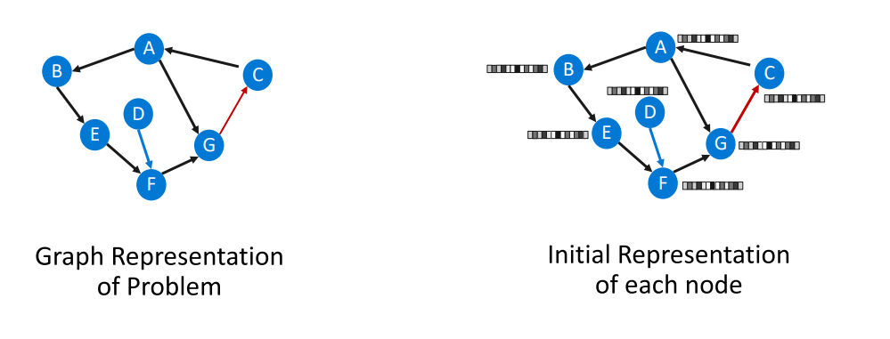

Screenshot from 2022-07-07 21-14-36.png

학습 중에 GNN은 해결해야 할 작업이나 문제에 특정한 정보를 반영하도록 이 노드 벡터를 업데이트합니다. 이는 반복적인 **메시지 전달(message passing)**을 통해 이루어집니다.

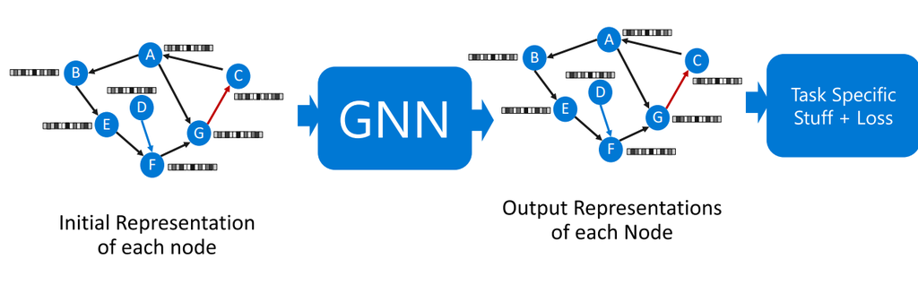

image.png

*Image Source: [An Introduction to Graph Neural Networks: Models and Application](https://www.youtube.com/watch?v=zCEYiCxrL_0&t=824s)*

## **GNN 이론: 메시지 전달**

### **메시지 전달**

그래프 합성곱 네트워크(GCN)에 대한 간단한 메시지 전달 방정식은 다음과 같이 표현할 수 있습니다:

# $$\mathbf{h}_i^{(k+1)} = \sigma \left( \sum_{j \in \mathcal{N}(i)} \frac{1}{\sqrt{d_i d_j}} \mathbf{W}^{(k)} \mathbf{h}_j^{(k)} \right)$$

각 구성 요소에 대한 설명은 다음과 같습니다:

- $\mathbf{h}_i^{(k+1)}$: 레이어 $k+1$에서 노드 $i$에 대한 업데이트된 노드 임베딩.
- $\mathbf{h}_j^{(k)}$: 현재 레이어 $k$에서 인접 노드 $j$의 임베딩.
- $\mathcal{N}(i)$: $i$의 인접 노드 집합.
- $d_i$ 및 $d_j$: 각각 노드 $i$와 $j$의 차수(degree). $\frac{1}{\sqrt{d_i d_j}}$ 항은 정규화 계수 역할을 합니다.
- $\mathbf{W}^{(k)}$: 레이어 $k$에 대한 가중치 행렬로, 학습 가능합니다.
- $\sigma$: 비선형성을 도입하기 위한 활성화 함수(예: ReLU).

이 방정식은 GCN의 핵심 연산을 나타냅니다. 각 노드에 대해 이웃의 특징을 집계하고, 정규화하고, $\mathbf{W}^{(k)}$로 변환하고, $\sigma$를 통과하여 다음 레이어에서 업데이트된 노드 임베딩을 얻습니다.

### **집계, 정규화 및 가중치 적용을 위한 GCN 방정식 분석**

# $$h_A^{(1)} = \sigma \left( \color{DarkMagenta}{\sum_{j \in \mathcal{N}(A)}} \ \color{CornflowerBlue}{\underbrace{\frac{1}{\sqrt{d_A d_B}}}_{\text{Normalization}}} \ \color{MediumSeaGreen}{\underbrace{W^{(0)}}_{\text{Weights}} \underbrace{h_B^{(0)}}_{\text{Neighbor's Features}}} \right)$$

### **주요 구성 요소:**

**가중치 적용(Applying Weights):**

- **방정식 부분**: $ W^{(0)} h_B^{(0)} $
- **설명**: 곱 $ W^{(0)} h_B^{(0)} $은 특징 벡터 $ h_B^{(0)} $에 **학습 가능한 가중치 행렬** $ W^{(0)} $를 적용합니다. 이 변환은 집계되기 전에 이웃의 특징을 조정합니다.

```python
# @title <font color='#569098'> **Step-by-Step Example of Message Passing in a GCN**

from IPython.core.display import display, HTML
import base64

# Paths to your images in Colab files
image_paths = [
    "/content/images/structure_text.png",  # First pair - Left structure text
    "/content/images/starting_structure.png",  # First pair - Right structure image
    "/content/images/initialize_text.png",  # Single image initialize text
    "/content/images/calculate_text.png",  # Single image calc text
    "/content/images/node_a_text.png",  # Second pair - Left node a text
    "/content/images/node_a.png",  # Second pair - Right node a image
    "/content/images/node_b_text.png",  # Third pair - Left node b text
    "/content/images/node_b.png",  # Third pair - Right node b image
    "/content/images/node_c_text.png",  # Fourth pair - Left node c text
    "/content/images/node_c.png",  # Fourth pair - Right node c image
    "/content/images/final_output_text.png", # Fifth pair - Left final output text
    "/content/images/final_structure.png"  # Fifth pair - Right final output image
]

# Titles for each section
titles = [
    "Step 1: Initialize Weights",
    "Step 2: Degree Calculation and Normalization",
    "Step 3: Aggregation and Update for Each Node",
    "Final Output After One Layer of Message Passing"
]

# Convert the images to base64 strings
base64_images = []
for path in image_paths:
    with open(path, "rb") as img_file:
        base64_images.append(base64.b64encode(img_file.read()).decode('utf-8'))

# Generate the HTML code
html_code = f"""
<div style="margin-bottom: 20px;">
    <div style="display: flex; justify-content: space-between; align-items: center; margin-bottom: 10px;">
        <div style="flex: 1; text-align: center; padding-right: 10px;">
            <img src="data:…" style="max-width: 100%;" />
        </div>
        <div style="flex: 1; text-align: center; padding-left: 10px;">
            <img src="data:…" style="max-width: 100%;" />
        </div>
    </div>
    <hr style="border: 1px solid #ddd; margin: 20px 0;">
</div>
<div style="margin-bottom: 20px;">
    <h3 style="color: #569098; font-size: 20px;"><b>{titles[0]}</b></h3>
    <div style="text-align: center; margin-bottom: 10px;">
        <img src="data:…" style="max-width: 100%;" />
    </div>
    <hr style="border: 1px solid #ddd; margin: 20px 0;">
</div>
<div style="margin-bottom: 20px;">
    <h3 style="color: #569098; font-size: 20px;"><b>{titles[1]}</b></h3>
    <div style="text-align: center; margin-bottom: 10px;">
        <img src="data:…" style="max-width: 100%;" />
    </div>
    <hr style="border: 1px solid #ddd; margin: 20px 0;">
</div>
<div style="margin-bottom: 20px;">
    <h3 style="color: #569098; font-size: 20px;"><b>{titles[2]}</b></h3>
    <div style="display: flex; justify-content: space-between; align-items: center; margin-bottom: 10px;">
        <div style="flex: 1; text-align: center; padding-right: 10px;">
            <img src="data:…" style="max-width: 100%;" />
        </div>
        <div style="flex: 1; text-align: center; padding-left: 10px;">
            <img src="data:…" style="max-width: 100%;" />
        </div>
    </div>
    <hr style="border: 1px solid #ddd; margin: 20px 0;">
</div>
<div style="margin-bottom: 20px;">
    <div style="display: flex; justify-content: space-between; align-items: center; margin-bottom: 10px;">
        <div style="flex: 1; text-align: center; padding-right: 10px;">
            <img src="data:…" style="max-width: 100%;" />
        </div>
        <div style="flex: 1; text-align: center; padding-left: 10px;">
            <img src="data:…" style="max-width: 100%;" />
        </div>
    </div>
    <hr style="border: 1px solid #ddd; margin: 20px 0;">
</div>
<div style="margin-bottom: 20px;">
    <div style="display: flex; justify-content: space-between; align-items: center; margin-bottom: 10px;">
        <div style="flex: 1; text-align: center; padding-right: 10px;">
            <img src="data:…" style="max-width: 100%;" />
        </div>
        <div style="flex: 1; text-align: center; padding-left: 10px;">
            <img src="data:…" style="max-width: 100%;" />
        </div>
    </div>
    <hr style="border: 1px solid #ddd; margin: 20px 0;">
</div>
<div style="margin-bottom: 20px;">
    <h3 style="color: #569098; font-size: 20px;"><b>{titles[3]}</b></h3>
    <div style="display: flex; justify-content: space-between; align-items: center; margin-bottom: 10px;">
        <div style="flex: 1; text-align: center; padding-right: 10px;">
            <img src="data:…" style="max-width: 100%;" />
        </div>
        <div style="flex: 1; text-align: center; padding-left: 10px;">
            <img src="data:…" style="max-width: 100%;" />
        </div>
    </div>
    <hr style="border: 1px solid #ddd; margin: 20px 0;">
</div>
"""

# Display the HTML
display(HTML(html_code))
```

[output not shown]

```python
from google.colab import drive
drive.mount('/content/drive')
```

```python
# @title **<font color='#569098'>GNN Theory: Permutation Invariance vs. Permutation Equivariance**

import matplotlib.pyplot as plt
from matplotlib.colors import LinearSegmentedColormap

# Helper function to plot the graph and its adjacency matrix
def plot_graph_and_matrix(G, pos, ax_graph, ax_matrix, title):
    # Plot the graph
    nx.draw(G, pos, with_labels=True, node_color='lightblue', ax=ax_graph)
    ax_graph.set_title(title)

    # Get the adjacency matrix
    adj_matrix = nx.adjacency_matrix(G).todense()

      # Create a lighter colormap based on Blues
    cmap = LinearSegmentedColormap.from_list("lighter_blues", ["#ffffff", "#cce5ff", "#6699cc"])

    # Plot the adjacency matrix
    ax_matrix.matshow(adj_matrix, cmap=cmap)
    for (i, j), val in np.ndenumerate(adj_matrix):
        ax_matrix.text(j, i, f'{val}', ha='center', va='center', color='black')
    ax_matrix.set_xticks([])
    ax_matrix.set_yticks([])

# Function to apply permutation and plot
def apply_permutation_and_plot(permutation_func, permutation_type, title):
    # Original graph
    G = nx.Graph()
    G.add_edges_from([(0, 1), (1, 2), (2, 3), (3, 0)])

    # Positions for original graph
    pos = nx.circular_layout(G)

    # Get og adjacency matrix
    adj_matrix = nx.adjacency_matrix(G).todense()


    # Apply permutation
    if permutation_type == "invariance":
        permuted_matrix = permutation_func(adj_matrix)
        G_permuted = nx.from_numpy_array(permuted_matrix)
        pos_permuted = pos
        equation = r"f(PX) = f(X)"
    elif permutation_type == "equivariance":
        permuted_matrix = permutation_func(adj_matrix)
        G_permuted = nx.from_numpy_array(permuted_matrix)
        pos_permuted = pos
        equation = r"f(PX) = Pf(X)"
    elif permutation_type == "unknown":
        permuted_matrix = permutation_func(adj_matrix)
        G_permuted = nx.from_numpy_array(permuted_matrix)
        pos_permuted = pos
        equation = r"???"
    else:
        raise ValueError("Permutation type must be 'invariance', 'equivariance', or 'unknown'.")


    # Plot results
    fig, axes = plt.subplots(1, 5, figsize=(8, 4))

    # Plot original graph and matrix
    plot_graph_and_matrix(G, pos, axes[0], axes[1], "Original Graph & Matrix")

    # Plot arrow with the equation
    axes[2].annotate("", xy=(1, 0.5), xytext=(0, 0.5), arrowprops=dict(arrowstyle="->", lw=2))
    axes[2].text(0.5, 0.6, equation, ha="center", fontsize=12)
    axes[2].axis('off')

    # Plot permuted graph and matrix
    plot_graph_and_matrix(G_permuted, pos_permuted, axes[3], axes[4], f"Permuted Graph & Matrix ({title})")

    plt.tight_layout()
    plt.show()



# og permutation functions
import numpy as np

# Invariant permutation function
def invariant_permutation(adj_matrix):
    """
    This function applies a permutation to simulate permutation invariance.
    The permutation does not change the adjacency matrix, reflecting invariance.
    """
    # No change to the adjacency matrix (invariant)
    return adj_matrix

# Equivariant permutation function
def equivariant_permutation(adj_matrix):
    """
    This function applies a permutation that simulates permutation equivariance.
    The permutation matrix P is applied to the adjacency matrix to reflect equivariance.
    """
    # Define the permutation matrix P for swapping nodes
    perm = [2, 0, 3, 1]  # Example permutation used in the original code
    P = np.eye(4, dtype=int)[perm]

    # Apply the permutation: P * adj_matrix * P.T and cast result to integers
    return (P @ adj_matrix @ P.T).astype(int)
```

- **순열 불변성(Permutation Invariance)**: 입력의 순서에 관계없이 출력이 동일하게 유지되는 경우 함수는 순열 불변입니다. 예를 들어, 노드 이웃의 정보를 집계할 때 이웃을 고려하는 순서가 집계 연산에 영향을 미치지 않아야 합니다. 합계, 평균, 최대값과 같은 일반적인 집계 함수는 자연스럽게 순열 불변입니다.

모든 순열 행렬 P에 대해 다음이 성립하면 f(X)는 순열 불변입니다:

$$f(PX) = f(X)$$

사용 시기: 전체 예측이 노드나 엣지의 특정 순서에 의존해서는 안 되는 그래프 분류와 같이 작업이 단일 출력으로 요약될 때 사용합니다.

```python
apply_permutation_and_plot(invariant_permutation, "invariance", "Invariant Permutation")
```

[figure not shown]

- **순열 등변성(Permutation Equivariance)**: 입력 순서가 순열될 때 출력이 입력과 동일한 방식으로 변경되는 경우 함수는 순열 등변입니다.

모든 순열 행렬 P에 대해 다음이 성립하면 f(X)는 순열 등변입니다:

$$f(PX) = Pf(X)$$

사용 시기: 작업이 노드 순서가 중요한 노드 수준 또는 엣지 수준 예측을 포함할 때, 즉 입력 노드와 해당 출력 간의 일관된 매핑을 유지해야 할 때 사용합니다.

```python
apply_permutation_and_plot(equivariant_permutation, "equivariance", "Equivariant Permutation")
```

[figure not shown]

### **작업: 아래의 순열 함수를 적용해보고 어느 것이 불변 또는 등변인지 확인하세요.**

**도움말 확인하려면 클릭**

```
apply_permutation_and_plot(identity_permutation, "unknown", "Identity Permutation") # invariant

apply_permutation_and_plot(reverse_permutation, "unknown", "Reverse Permutation") # invariant

apply_permutation_and_plot(swap_permutation, "unknown", "Swap Permutation") # equivariant
```

```python
# Simple permutation functions
def identity_permutation(adj_matrix):
    return adj_matrix

def reverse_permutation(adj_matrix):
    P = np.array([[0, 0, 0, 1],
                  [0, 0, 1, 0],
                  [0, 1, 0, 0],
                  [1, 0, 0, 0]])
    return P @ adj_matrix @ P.T

def swap_permutation(adj_matrix):
    P = np.array([[0, 1, 0, 0],
                  [1, 0, 0, 0],
                  [0, 0, 1, 0],
                  [0, 0, 0, 1]])
    return P @ adj_matrix @ P.T

# YOUR CODE HERE, Try applying the permutation functions and identify if they are invariant or equivariant
# raise NotImplementedError()
```

```python
#@markdown **<font color='#e59454'>Question Time! Run to Show Question**

from IPython.display import display, HTML

def create_all_correct_quiz(question, answers_with_explanations):
    # Shuffle answers randomly
    answers = list(answers_with_explanations.keys())
    random.shuffle(answers)

    # Generate the HTML code
    html_code = f"""<div style="font-family: Arial, sans-serif; margin: 30px; max-width: 1000px;">
    <h3 style="word-wrap: break-word;">{question}</h3>"""

    # Add each answer as a checkbox
    for i, answer in enumerate(answers):
        html_code += f"""
        <div style="word-wrap: break-word; margin-bottom: 10px;">
        <input type="checkbox" id="option{i}" name="quiz" value="{answer}">
        <label for="option{i}" id="label{i}">{answer}</label>
        </div>"""

    # Add the submit button and feedback section
    html_code += """
    <button onclick="showExplanations()">Submit</button>
    <div id="explanations" style="display: none; margin-top: 20px; font-weight: bold;">
        <h4>Explanations:</h4>
        <ul>"""

    # Add explanations
    for answer, explanation in answers_with_explanations.items():
        html_code += f"<li><b>{answer}:</b> {explanation}</li>"

    html_code += """
        </ul>
    </div>
    </div>
    <script>
    function showExplanations() {
        var explanations = document.getElementById('explanations');
        explanations.style.display = 'block';
    }
    </script>"""

    display(HTML(html_code))


# Usage
question = "Which of the following tasks would you need invariance for?"
answers_with_explanations = {
    "All are correct.": """Technically each of these tasks requires invariance because they all require message passing."
    "Please read below for more specific details on invariance for each task.""",
    "Predicting the binding affinity of a protein to a ligand.": """
        This task requires invariance because the prediction should be independent of
        the specific ordering of the atoms or residues in the protein. The model
        should produce the same binding affinity regardless of how the protein’s atoms
        are ordered in the input. Since the task involves a global property of the entire
        protein-ligand complex, invariance is crucial.
    """,
    "Identifying the most likely catalytic residues in an enzyme.": """
        This task requires equivariance, not invariance, because the model needs to
        identify specific residues within the protein. The order of the residues in the
        input matters, as you want to know which exact amino acids are catalytic. If
        the order of nodes changes, the output nodes should change accordingly.
    """,
    "Classifying proteins based on their overall structural fold.": """
        This task requires invariance because the classification of the protein's
        structural fold should not depend on the order in which the secondary structure
        elements (like helices or sheets) are presented. The overall fold is a global
        property, so invariance is necessary to ensure that different permutations of the
        input give the same classification result.
    """,
    "Predicting the effect of a mutation on a specific residue within a protein.": """
        This task requires equivariance because the prediction is localized to a specific
        residue and its neighboring residues. The model must maintain the relationship
        between the input residue and its output prediction, so if the residue order
        changes, the output should change correspondingly.
    """
}

create_all_correct_quiz(question, answers_with_explanations)
```

Which of the following tasks would you need invariance for?

Predicting the effect of a mutation on a specific residue within a protein.

Predicting the binding affinity of a protein to a ligand.

Identifying the most likely catalytic residues in an enzyme.

All are correct.

Classifying proteins based on their overall structural fold.

# **섹션 3: GCN 구현**

## **GCN 구현: 입력 데이터 로드 및 준비**

우리는 [Amemiya et al. (2011)](https://academic.oup.com/nar/article/40/D1/D554/2903618)의 PSCDB 데이터셋을 사용할 것입니다. 이 데이터셋에는 결합 및 비결합 형태의 839개 단백질 구조 쌍의 pdb 파일이 포함되어 있으며 7가지 구조적 재배열 동작 클래스(결합 도메인 동작, 독립 도메인 동작, 결합 로컬 동작, 독립 로컬 동작, 리간드 매립 동작, 유의미한 동작 없음, 기타 유형 동작)에 걸쳐 있습니다.

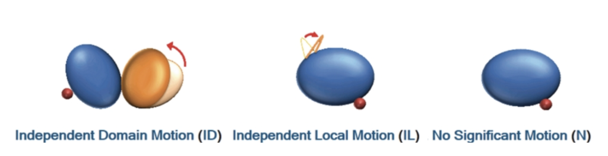

Screenshot 2024-09-17 at 12.33.12 PM.png

*이미지는 다음 기사에서 각색됨: [PSCDB: 리간드 결합 시 단백질 구조 변화를 위한 데이터베이스](https://www.researchgate.net/publication/51796031_PSCDB_A_database_for_protein_structural_change_upon_ligand_binding)*

```python
# Get the .pdb files
!git clone https://github.com/courtel/GNN_dl_workshop

# Load the DataFrame from the CSV file that contains motion info
df_pscdb = pd.read_csv('/GNN_dl_workshop/df_pscdb.csv')

# Display the DataFrame to confirm it's loaded correctly
print(df_pscdb.head())
```

```
fatal: destination path 'GNN_dl_workshop' already exists and is not an empty directory.
   Unnamed: 0  level_0  index PSCID  \
0           1        1      1  CD.2
1           4        4      4  CD.5
2           5        5      5  CD.6
3           6        6      6  CD.7
4           8        8      8  CD.9

                                   Protein Name Free form Bound form  Ligands  \
0                              ADENYLATE KINASE    4ake_A     2eck_A  ADP,AMP
1                           ELONGATION FACTOR 2    1n0v_D     1n0u_A      SO1
2                              CITRATE SYNTHASE   5csc_AB    6cts_AA    2xCIC
3                  ARACHIDONATE 15-LIPOXYGENASE    2p0m_A     2p0m_B      RS7
4  3-PHOSPHOSHIKIMATE 1-CARBOXYVINYLTRANSFERASE    2bjb_A     2o0d_A      S3P

   Classification(?)            motion_type free_pdb Free Chains Bound PDB  \
0             200003  coupled_domain_motion     4ake           A      2eck
1             110002  coupled_domain_motion     1n0v           D      1n0u
2             102001  coupled_domain_motion     5csc          AB      6cts
3             101201  coupled_domain_motion     2p0m           A      2p0m
4             101101  coupled_domain_motion     2bjb           A      2o0d

  Bound Chains
0            A
1            A
2           AA
3            B
4            A
```

```python
# @title **Data Prep Functions**

# Define a function to map motion class
motion_type_mapping = {row['free_pdb']: row['motion_type'] for _, row in df_pscdb.iterrows()}
# print("motion_type_mapping", motion_type_mapping)

# Convert motion types to numerical labels
motion_type_to_label = {motion_type: idx for idx, motion_type in enumerate(df_pscdb['motion_type'].unique())}

def classification_mapping(df_pscdb, data):
    protein_name = data.name
    motion_type = motion_type_mapping[protein_name]
    # print("motion type", motion_type)
    graph_label = motion_type_to_label[motion_type]
    # print("graph label", graph_label)
    # data.graph_y = torch.tensor([graph_label])
    data.graph_y = graph_label
    # print("graph_y", data.graph_y)
    return data

# Define a function to parse pdb and convert to networkx then to pytorch object
def get_distance_matrix(coords):
    diff_tensor = np.expand_dims(coords, axis=1) - np.expand_dims(coords, axis=0)
    distance_matrix = np.sqrt(np.sum(np.power(diff_tensor, 2), axis=-1))
    return distance_matrix

def pdb_to_graph(pdb_path, distance_threshold=6.0, contain_b_factor=True):
    atom_df = PandasPdb().read_pdb(pdb_path)
    atom_df = atom_df.df['ATOM']
    residue_df = atom_df.groupby('residue_number', as_index=False)[['x_coord', 'y_coord', 'z_coord', 'b_factor']].mean().sort_values('residue_number')
    coords = residue_df[['x_coord', 'y_coord', 'z_coord']].values
    distance_matrix = get_distance_matrix(coords)
    adj = distance_matrix < distance_threshold
    u, v = np.nonzero(adj)
    u, v = torch.from_numpy(u), torch.from_numpy(v)
    graph = nx.Graph()

    # Add nodes with coordinates and b_factor included in the node feature matrix 'x'
    for i, row in residue_df.iterrows():
        node_features = [row['x_coord'], row['y_coord'], row['z_coord']]
        if contain_b_factor:
            node_features.append(row['b_factor'])  # Append b_factor to the features
        graph.add_node(i, x=torch.tensor(node_features, dtype=torch.float))

    # Add edges based on the adjacency matrix
    for src, dst in zip(u.numpy(), v.numpy()):
        distance = distance_matrix[src, dst]
        graph.add_edge(src, dst, edge_attr=torch.tensor([distance], dtype=torch.float))

    return graph


def get_pmolecule(file_path, distance_threshold=6.0, contain_b_factor=True, train=True):
    # Create a graph using pdb_to_graph
    graph = pdb_to_graph(file_path, distance_threshold, contain_b_factor)

    # Convert to PyTorch data object
    data = from_networkx(graph)

    # Set the name attribute manually
    data.name = os.path.basename(file_path).replace('.pdb', '')

    # Check that there are feats
    if 'x' not in data:
        print("warning, no x node features")

    if 'edge_attr' not in data:
        print("warning, no edge attributes")

    # Add labels for motion_type
    data = classification_mapping(df_pscdb, data)

    return data

def get_pyg_data_list(pdb_directory, pdb_id=None, distance_threshold=6.0, contain_b_factor=True, train=True):
    pdb_files = [f for f in os.listdir(pdb_directory) if f.endswith('.pdb')]
    pyg_data_list = []

    if train:
        for pdb_file in pdb_files:
            file_path = os.path.join(pdb_directory, pdb_file)
            graph = get_pmolecule(file_path, distance_threshold, contain_b_factor)
            pyg_data_list.append(graph)
        return pyg_data_list
    else:
        file_path = os.path.join(pdb_directory, f'{pdb_id}.pdb')
        pyg_data = get_pmolecule(file_path, distance_threshold, contain_b_factor, train=False)
        return pyg_data
```

GCN의 입력으로 .pdb 파일을 준비하는 것은 원래 단백질을 나타내는 노드와 엣지의 그래프를 생성하기 위해 정보를 추출하는 것을 포함합니다. 그런 다음 데이터는 특징이 텐서로 표현되는 pytorch 데이터 객체로 변환됩니다.